# Project 1 Solution

# Part 6: Make my plot a better plot

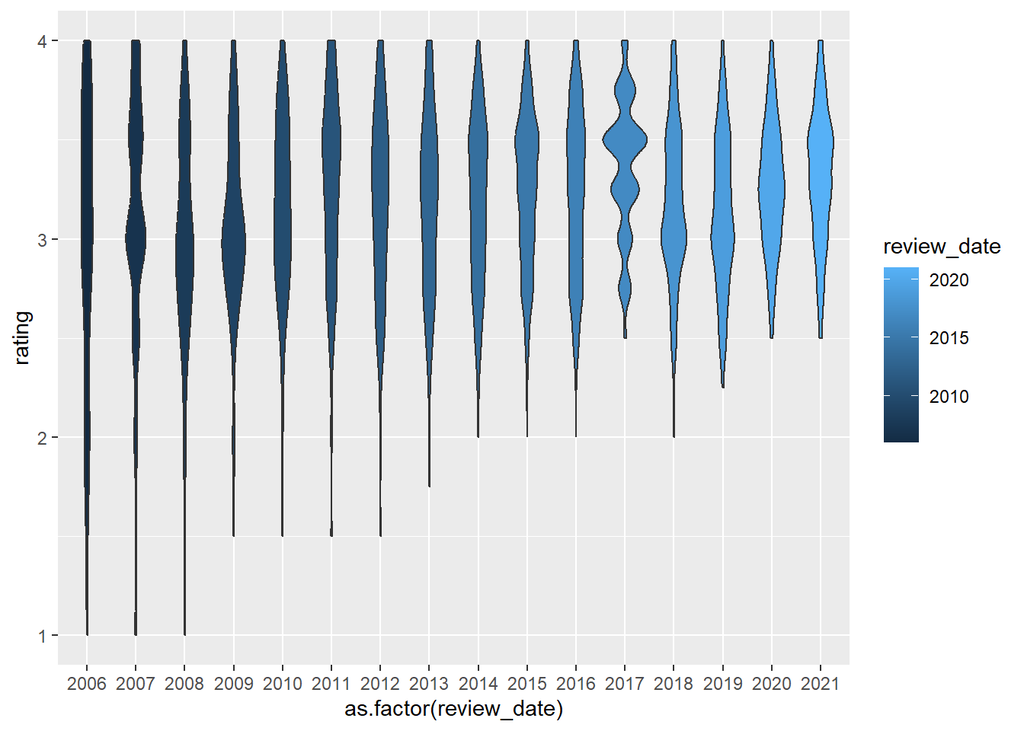

```r
# Original Plot
chocolate %>%
    ggplot(aes(
        x = as.factor(review_date),
        y = rating,
        fill = review_date
    )) +
    geom_violin()
```

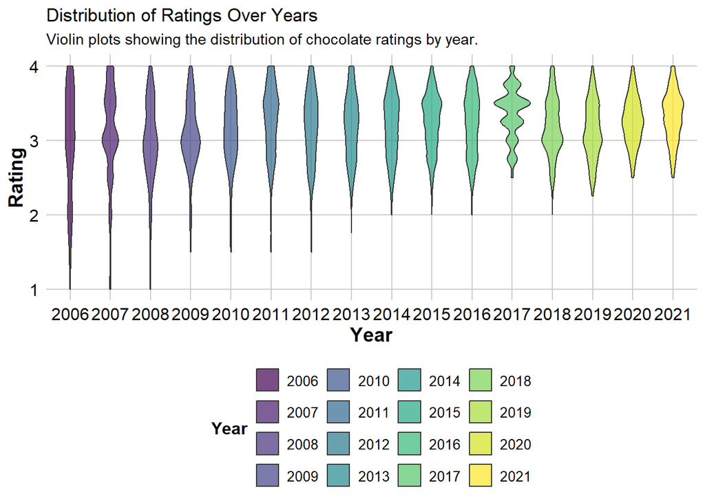

```r
# Modified Plot
# Improved Plot
ggplot(chocolate, aes(x = as.factor(review_date), y = rating, fill = as.factor(review_date))) +
  geom_violin(alpha = 0.7) +  # Semi-transparent violin plots for better clarity
  scale_fill_viridis_d() +  # Use a color palette from viridis for better color perception
  labs(
    title = "Distribution of Ratings Over Years",
    subtitle = "Violin plots showing the distribution of chocolate ratings by year.",
    x = "Year",
    y = "Rating",
    fill = "Year"
  ) +
  theme_minimal() +  # Clean, minimal theme
  theme(
    panel.grid.major = element_line(color = "gray80"),  # Light gray grid lines
    panel.grid.minor = element_blank(),  # Remove minor grid lines for clarity
    axis.text = element_text(size = 12, color = "black"),  # Readable axis text
    axis.title = element_text(size = 14, face = "bold"),  # Bold axis titles for emphasis
    legend.position = "bottom",  # Place legend at the bottom
    legend.title = element_text(size = 12, face = "bold"),  # Bold legend title
    legend.text = element_text(size = 10)  # Slightly smaller legend text
  )
```

# 1) Transparency was added to the biolin plots to allow overlapping featrues to be more readily seen. # 2) I used the viridis package, which is a uniform color palette and is color-bling friendly to enchance the color differentiation between the years and to make the plot more accessible to read. # 3) I added a title and subtitle along with access labels in order to make it more clear the purpose of the plot and what is being plotted. # 4) I used the “theme_minimal()” function to reduce the number of things on the plot to increase redability. # 5) I added light gray grid lines to make it easier to compare the chocolate ratings while making them subtle enough so that they weren’t distracting. # 6) I changed the font size of the axis tect to 12 and the color to black to make the axis labels easier to read. # 7) I moved the legend to the bottom of the plot, separating it from the plot itself, and making it less likely to overlap with the data.

```r
# R Session Information
options(width = 120)
```